# Analysis and Comparison of Pitch Estimation Algorithms - YIN vs P-YIN

### Krishna Subramani, 150020008

### An introduction to the problem -

- What is **pitch**? - Can be 'loosely' defined as the fundamental frequency$(F_0 = \frac{1}{T_0})$(reciprocal of fundamental period) of an audio signal. Mathematically, \begin{align} &\min_{T} x(t + T) = x(t) \tag{1} \label{e1}\\ \end{align} Although, to be more precise, pitch is a **perceptual construct** as opposed to $F_0$, though they are related.
- We will discuss the **YIN** algorithm first, and then present a motivation to move on to a better estimator, the **P-YIN**(Probabilistic-YIN)

```python
# Dependencies
import numpy as np
import essentia
import essentia.standard as ess
import matplotlib.pyplot as pyp
import IPython.display as ipd
import matplotlib
```

```python
def genAudioTone(pitch, hopSize = 128, fs = 44100):
    """
    Generates pure sine tone audio data from the pitch contour

    Parameters
    ----------
    pitch : list
        pitch contour data as a list

    Returns
    -------
    x : np.array
        audio data to play or write wav files

    """
    x = np.array([])
    phase = 0.0

    for frame_no in range(len(pitch)):
        tone = 1.0 * np.cos((2*np.pi*pitch[frame_no]*np.arange(hopSize)/44100) + phase)
        x = np.append(x, tone)
        phase = phase + 2*np.pi*pitch[frame_no]*(hopSize-1)/fs

    return x
```

```python
# Load audio
Fs = 44100
audio1 = ess.MonoLoader(sampleRate = Fs,filename = 'audio1.wav')()
```

```python
# Playing the loaded audio
ipd.Audio(audio1, rate=Fs)
```

[interactive chart not shown]

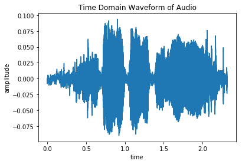

```python
# Plotting the Audio and its spectrogram
pyp.figure()
pyp.title('Time Domain Waveform of Audio')
pyp.xlabel('time')
pyp.ylabel('amplitude')
t = np.arange(len(audio1))*1.0/Fs
pyp.plot(t,audio1);
```

```python
W = 1024
H = 512
w = ess.Windowing(type = 'hann')
fft = ess.FFT()
c2p = ess.CartesianToPolar()
pool = essentia.Pool()
acf = ess.AutoCorrelation()

for frame in ess.FrameGenerator(audio1, frameSize = W, hopSize = H):
    mag, phase, = c2p(fft(w(frame)))
    autocorr = acf(w(frame))
    pool.add('mag_spec', mag)
    pool.add('phase_spec', phase)
    pool.add('acf',autocorr)
```

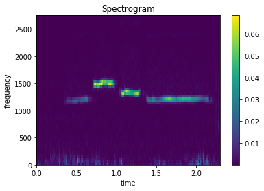

```python
freq = np.arange((int)(W/2) + 1)*(Fs/W)
t = np.arange(len(pool['mag_spec']))*(len(audio1)/Fs)/(len(pool['mag_spec']))
pyp.imshow(pool['mag_spec'][:,0:64].T,origin = 'lower',aspect='auto',extent=[t[0],t[-1], freq[0],freq[64]])
pyp.colorbar()
pyp.title('Spectrogram')
pyp.xlabel('time')
pyp.ylabel('frequency');
```

### YIN algorithm -

- The fundamental working behind this algorithm is to find the solution to the Eq. 1 above. We can do this in the two following ways by solving equivalent problems -
  1. We can find the peaks in the autocorrelation function which correspond to periodicities in the signal \begin{align}

     ```
      r_{t}(\tau) = \sum_{j = t+1}^{t+W} x[j]x[j+\tau]
     ```

     \end{align}
  2. We can find the Magnitude Squared difference(**MDF**) of Eq. 1 and find the period T which minimizes it i.e. \begin{align}

     ```
      d_{t}(\tau) = \sum_{j = 1}^{W} (x[j] - x[j+\tau])^{2} \label{2}
     ```

     \end{align}
- The YIN algorithm uses a modification of Eq. 2 above by performing some normalization on it.
- A sample MDF for a certain frame is shown below

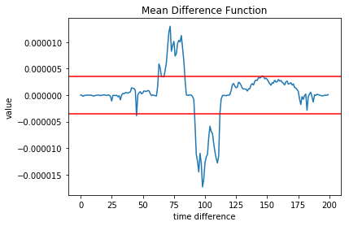

```python
# YIN Algorithm
# Calculation of MDF
mdf = np.zeros(200)
ti = 100
for i in range(200):
    mdf[i] = pool['acf'][:,ti][0] + pool['acf'][:,ti + 1][0] - 2*pool['acf'][:,ti][i]
pyp.plot(mdf)
pyp.axhline(0.0000035,color = 'r')
pyp.axhline(-0.0000035,color = 'r')
pyp.title('Mean Difference Function')
pyp.xlabel('time difference')
pyp.ylabel('value');
```

- Once the MDF is computed, what YIN does is select a certain threshold below which the potential candidates are found. Those are the points where $d'(\tau) = 0$(local minima essentially).
- In the above case, multiple local minima are detected. In that case, choose that value of $\tau$ which is the minimum.

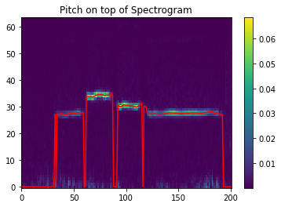

```python
# YIN from essentia
yin = ess.PitchYin(frameSize = W,interpolate = True,tolerance = 1)
pyt = []
ct = []
for frame in ess.FrameGenerator(audio1, frameSize = W, hopSize = H):
    py,c = yin(frame)
    pyt.append(py)
    ct.append(c)
pyt = np.asarray(pyt)
ct = np.asarray(ct)

pyp.imshow(pool['mag_spec'][:,0:64].T,origin = 'lower',aspect='auto')
pyp.colorbar()
pyp.plot(pyt*(ct>0.5)*(W/Fs),color = 'r')
pyp.title('Pitch on top of Spectrogram');
```

```python
# Audio corresponding to extracted pitch
ipd.Audio(genAudioTone(pyt*(ct>0.5),H,Fs), rate=Fs)
```

[interactive chart not shown]

- One thing you will immediately think is how to select the threshold. The authors in the original paper for YIN present some heuristic methods to select the threshold values. However, there is no generic 'universal' method.
- This presents a problem in certain cases(for example if the pitch is varying rapidly). An example is shown below

```python
audio_ex = ess.MonoLoader(sampleRate = Fs,filename = 'small_lyrics.wav')()
# Playing the loaded audio
ipd.Audio(audio_ex, rate=Fs)
```

[interactive chart not shown]

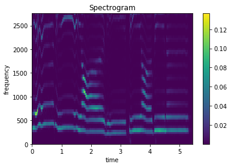

```python
W = 1024
H = 512
w = ess.Windowing(type = 'hann')
fft = ess.FFT()
c2p = ess.CartesianToPolar()
pool1 = essentia.Pool()
acf = ess.AutoCorrelation()

for frame in ess.FrameGenerator(audio_ex, frameSize = W, hopSize = H):
    mag, phase, = c2p(fft(w(frame)))
    autocorr = acf(w(frame))
    pool1.add('mag_spec', mag)
    pool1.add('phase_spec', phase)
    pool1.add('acf',autocorr)

freq = np.arange((int)(W/2) + 1)*(Fs/W)
t = np.arange(len(pool1['mag_spec']))*(len(audio_ex)/Fs)/(len(pool1['mag_spec']))
pyp.imshow(pool1['mag_spec'][:,0:64].T,origin = 'lower',aspect='auto',extent=[t[0],t[-1], freq[0],freq[64]])
pyp.colorbar()
pyp.title('Spectrogram')
pyp.xlabel('time')
pyp.ylabel('frequency');
```

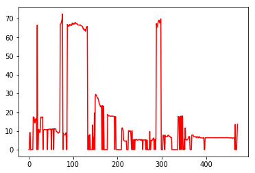

```python
# YIN from essentia
yin = ess.PitchYin(frameSize = W,interpolate = True,tolerance = 1)
pyt = []
ct = []
for frame in ess.FrameGenerator(audio_ex, frameSize = W, hopSize = H):
    py,c = yin(frame)
    pyt.append(py)
    ct.append(c)
pyt = np.asarray(pyt)
ct = np.asarray(ct)
pyp.plot(pyt*(ct>0.2)*(W/Fs),color = 'r');
```

```python
ipd.Audio(genAudioTone(pyt*(ct>0.2),H,Fs), rate=Fs)
```

[interactive chart not shown]

As we can see in the above example, the YIN algorithm fails to extract the pitch correctly due to its variable nature.  
This is one of the major motivations to move onto the **P-YIN** algorithm. It follows the same steps as the YIN upto the extraction of the MDF, however, after this stage, the procedure is changed.

- Instead of having a constant threshold, you define a distribution of thresholds governed by a density function. Thus, for each value of the threshold, you will get an estimate.
- The distribution used is shown below -

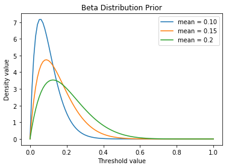

```python
# PYIN
# Considering same MDF from before -
from scipy.stats import beta
a, b = 2.30984964515, 0.62687954301
rv1 = beta(2, 18)
rv2 = beta(2,11.33)
rv3 = beta(2,8)
x = np.linspace(0,1,100)
pyp.figure()
pyp.plot(x,rv1.pdf(x),label = 'mean = 0.10')
pyp.plot(x,rv2.pdf(x),label = 'mean = 0.15')
pyp.plot(x,rv3.pdf(x),label = 'mean = 0.2')
pyp.legend(loc = 'best')
pyp.title('Beta Distribution Prior')
pyp.xlabel('Threshold value')
pyp.ylabel('Density value');
```

- Thus, the thresholds are distributed according to the beta distribution above.
- For each threshold, you will obtain an estimate. Very roughly speaking, the overall estimate can be written as - \begin{align}

  ```
    P(\tau = \tau_0) = \sum_{i}P(\tau = \tau_0|s_i)P(s_i)
  ```

  \end{align}
- This is exactly what the authors try to model in the P-YIN paper. They find the probabilities corresponding to each $\tau_0$ being a threshold.
- Thus, the output of the P-YIN algorithm are the possible pitch values and the corresponding probabilities.

Now, this is where the authors use the concept of a **Markov Model** to model the underlying dynamics of the pitch evolution. They discretize the pitch space, and use the above obtained probabilities as the **emission probabilities** in a **Hidden Markov Model**. Thus, the task boils down to finding the most likely pitch sequence given the emissions. This is done using the Viterbi algorithm for the Maximum Likelihood Sequence Estimation.

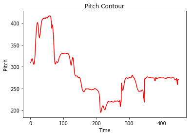

```python
# PYin using essentia
pyin = ess.PitchYinProbabilistic(frameSize = W,hopSize = H,lowRMSThreshold = 0.0001,preciseTime = True)
pyin_p,vp = pyin(audio_ex)

pyp.figure()
pyp.plot(pyin_p[pyin_p>0],color = 'r')
pyp.title('Pitch Contour')
pyp.xlabel('Time')
pyp.ylabel('Pitch');
```

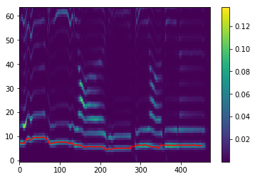

```python
pyp.figure()
pyp.imshow(pool1['mag_spec'][:,0:64].T,origin = 'lower',aspect='auto')
pyp.colorbar()
pyp.plot(pyin_p[pyin_p>0]*(W/Fs),color = 'r');
```

```python
# Pitch Track generated by P-YIN
ipd.Audio(genAudioTone(pyin_p[pyin_p>0],H,Fs), rate=Fs)
```

[interactive chart not shown]

## References

1. De Cheveigné, Alain, and Hideki Kawahara. "YIN, a fundamental frequency estimator for speech and music." The Journal of the Acoustical Society of America 111.4 (2002): 1917-1930.
2. Mauch, Matthias, and Simon Dixon. "pYIN: A fundamental frequency estimator using probabilistic threshold distributions." 2014 IEEE International Conference on Acoustics, Speech and Signal Processing (ICASSP). IEEE, 2014.